# Exploratory Analysis

## High School Student Alcohol Consumption and Related Factors

### Authors

Josefina Albert: jalbert5@uw.edu

Caroline Fang: ytf113@uw.edu

Yusen Liang: yusenl2@uw.edu

Zulin Luo: lawclrr@uw.edu

### Date

Winter 2/20/2022

### Abstract

Our project aims to find relationships between students’ alcohol consumption and different factors by analyzing the dataset. The dataset provides information that allows us to find ways to help students improve their academic performances and reduce their alcohol consumption by analyzing the factors, including various social, economic, academic, and environmental variables, and alcohol consumption ratings.

### Keywords

High School Student; Alcohol Consumption; Family background; Educational Levels; Academic Performance

### Introduction

For our project, we want to analyze how different factors and high school students’ alcohol consumption behavior are related to each other. It is important to understand what is influencing the habit of student drinking, and how their drinking behavior will affect their class/academic performance. There are four questions we want to mainly explore with the data:

1. Which gender has a higher average rating on workday and weekend alcohol consumption?
2. Does the amount of student alcohol consumption depends on the amount of free time afterschool they have?
3. How does alcohol consumption impact academic performance among students?
4. Were there any factors that correlated with lower alcohol consumption levels?

The dataset we choose from Kaggle provides us with data about the general background of the student and their family. It also records student’s drinking level and their grades over three periods for Math class and Portuguese language class. For our project, we plan to use the data from the Math class dataset for analysis. We want to explore if any factors recorded in the dataset are related to the level of students’ alcohol consumption. Specifically, we want to examine if there is a relationship between student alcohol consumption and factors like gender, family relationships, and parents’ education level. And also, we wonder what contributes to the most positive and negative effects on student’s academic success. Our project aims to find ways to help high school students improve their academic performances and reduce their alcohol consumption.

### Related Work

Alcohol consumption among adolescents has become one of the public health problems of global concern. Compared with adults, adolescents are physically and psychologically immature. The consequences of alcohol will not only affect the health of young people, but also easily lead to inappropriate violence or sexual behavior, traffic accidents, interrelationship influence, and academic grade fluctuation. These three articles describe drinking among high school students from the United States, Canada, and northeastern Portugal. They all collected data on the age, gender, academic performance, and frequency and amount of drinking of the study student population. These factors are all connected to the dataset we studied, and we can use the data of these three additional research articles to compare and study their data and results. In the study “The effects of alcohol use on academic achievement in high school, Economics of Education Review”, researchers examine the relationship between student alcohol consumption and student grade point average (GPA) using data from the U.S. National Longitudinal Study of Adolescent Health. The article found that alcohol consumption had a small negative effect on male students’ GPAs and no significant effect on female students’ GPAs. However, alcohol consumption increased school absences and difficulty completing school-related tasks. In another study “Identifying patterns of alcohol use among secondary school students in Canada: A multilevel latent class analysis”, researchers aim to see if there are some social or family factors associated with the amount and pattern of alcohol consumption among students. The article found a significant association between gender and membership in the alcohol drinking level (nondrinkers to heavy drinkers), with the male sex being associated with increased odds of membership in high-risk drinking groups. Other factors are not as significantly associated with alcohol consumption as the gender factor. We also include the study “Pattern of Alcohol Consumption by Young People from North Eastern Portugal” to support and cross-analyze our dataset since our dataset collects information from two Portugal schools. This study also classified students’ drinking behavior and analyze their academic performances. With these three data, we can comprehensively judge whether there are some same phenomena or factors that lead to students’ drinking behaviors and habits by comparing the conditions of different countries and the included research factors. And also look if there are some supplements or related information that we can use for our project’s later progress.

Reference:

Ana I. Balsa, Laura M. Giuliano, Michael T. French, The effects of alcohol use on academic achievement in high school, Economics of Education Review, Volume 30, Issue 1, 2011, Pages 1-15, ISSN 0272-7757, https://doi.org/10.1016/j.econedurev.2010.06.015.

Mahmood R. Gohari, Richard J. Cook, Joel A. Dubin, Scott T. Leatherdale, Identifying patterns of alcohol use among secondary school students in Canada: A multilevel latent class analysis, Addictive Behaviors, Volume 100, 2020, 106120, ISSN 0306-4603, https://doi.org/10.1016/j.addbeh.2019.106120.

Gonçalves, I. A., & Carvalho, A. A. S. (2017). Pattern of Alcohol Consumption by Young People from North Eastern Portugal. Open medicine (Warsaw, Poland), 12, 494–500. https://doi.org/10.1515/med-2017-0068

### The Dataset

Where did you find the data? Please include a link to the data source  
We find our dataset from kaggle, and here is the link to the data source: https://www.kaggle.com/datasets/uciml/student-alcohol-consumption

Who collected the data? P. Cortez and A. Silva. Using Data Mining to Predict Secondary School Student Performance. A. Brito and J. Teixeira Eds., Proceedings of 5th Future Business Technology Conference

How was the data collected or generated?  
The UCI machine learning repository generated this dataset based on two previous studies of alcohol consumption in students.

Why was the data collected?  
This data was collected to compare and make observations about a variety of factors and effects on students’ alcohol consumption.

How many features (columns) are in the data?  
There are 33 columns.

What, if any, ethical questions or questions of power do you need to consider when working with this data?  
As our data compares a variety of socio-economic factors with a student’s chosen behavior, we need to understand the imbalances in resources and support among the participants of the study, and the effect that may have on their chosen behaviors. Additionally, it can be easy to categorize certain behaviors as negative, but as data scientists it’s important to look at all observations through a non-biased lens.

What are possible limitations or problems with this data? (at least 200 words) This data set deals with a variety of environmental factors that could potentially impact a student and then compares them to their specific patterns and behaviors, including the consumption of alcohol. These factors include everything from their age, sex, address, parent’s occupations, absences, academic failings, and health. Throughout our project, we must refer to the notion that correlation does not always equal causation. Some of these factors, such as a mother or father’s job, may align with a higher amount of alcohol consumption of a student but not be the actual cause for that consumption amount. We will have to take this into consideration when making conclusions for certain trends that we may observe throughout the project. Additionally, some of our information is self-reported data, and there may be a margin of error where some participants didn’t answer realistically or honestly. The participants are school aged young adults who may not want to answer truthfully personal factors such as the amount of alcohol they chose to consume or how often they go out. The most accurate information for each participant may be impossible to ever really know, so we will have to use the data we are given and make our best conclusions to our research questions after evaluating the data.

### Implications

Student alcohol consumption has been a controversial social issue. From the dataset we analyze, we’ll be able to see the possible correlations, not necessarily direct cause and effect relationships, between alcohol consumption and many other factors. Then we’ll be able to see if it is alcohol leading to certain behaviors, or it is under certain conditions students consume more alcohol. For example, people can see visually the correlations between alcohol consumption of the students with their family size, presence of both parents, and education levels of parents, etc. By reading the data, we’ll be able to answer questions like “What are the most possible factors that cause students to consume alcohol more?” and “What are the most direct influences brought by the over-consuming of alcohol?” Psychologists and policymakers could use such data to help analyze teenagers’ mental health conditions and to aid mentally or physically. And although not very broad, the two datasets in two different classes help a bit in providing less variances and less biases in the data. We might look more into combining the two datasets in the future analysis.

### Limitations & Challenges

We’ve never utilized Github for group collaboration before. We spent some time working out how to submit our own component without interfering with the work of the other team members. We decided to use Google Docs to capture each team member’s ideas and suggestions for the responsible portion of other team members because it is tough to find a time to get everyone together to discuss the project because we all have various schedules. This can considerably improve our efficiency. Narrowing down our topics at the outset of a project is the hardest part. In the beginning, we also had some difficulties with the choice of data sets. The datasets we found for some of the genres we are interested in have some issues, such as not enough observations, not enough characteristics, or the provided features are not conducive to our data analysis. We attempt to list all potential data sets in Google Docs, and we select the ones we wish to study based on our ability to elicit relevant research questions.

One possible challenge for the broad idea of the project might be that because our data is only extracted from students in 2 schools, the sample range is not broad enough for the result to be globally applicable. For example, the data cannot be convincing enough to represent countries like the US because of legal drinking age limits the data the are allowed to be extracted. Therefore, we can only imply a correlation between students’ alcohol consumption and other factors, instead of clearly proving a direct causal relationship between alcohol consumption and other factors. There will also be a limit in the dataset we currently have, which are caused by some missing data and unclear data in this dataset. For example, many data under column “father’s job” contains an “other” value instead of a specific job title. It would somehow influence the data interpretation. This might be improved if we could collect a supplemental dataset from other resources.

### Chart 1 (Caroline Fang)

I chose this chart to analyze the relationship between the amount of student alcohol consumption and the amount of free time after school. The reason I chose the boxplot is that it is helpful to display the distribution of student alcohol consumption with different free time after school and some outliers which may influence the result. The chart exhibits that the elongation of free time after school will increase the amount of student alcohol consumption.

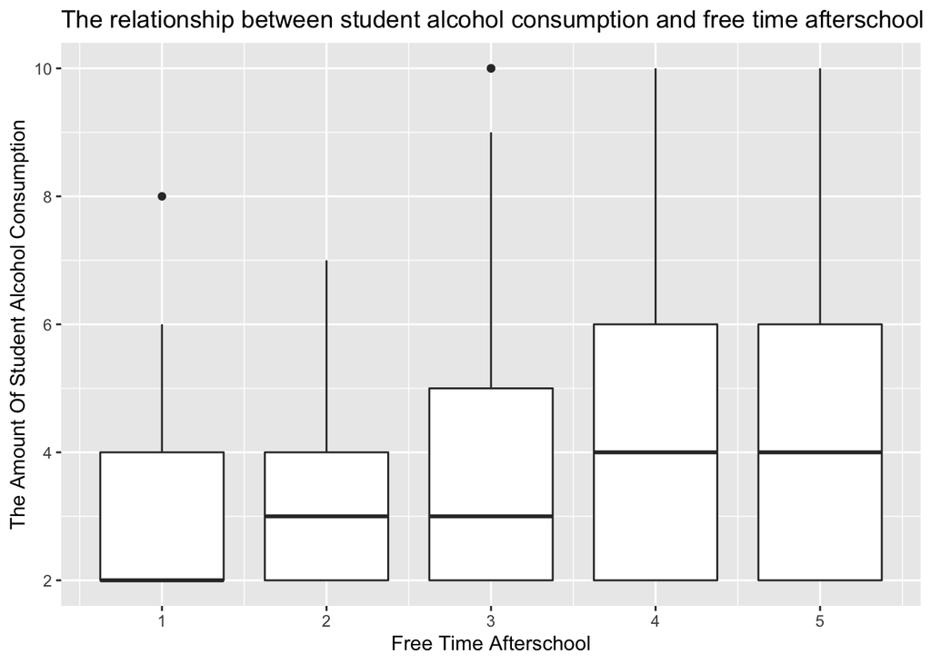

### Chart 2 (Josefina Albert)

I chose to create a scatterplot displaying a factor that correlates with lower alcohol consumption levels. To do this, I looked at the data and decided to evaluate the effect age had on alcohol consumptin. I grouped each age by year and then found an average for each years alcohol consumption. From here I made a data frame with two columns and created a scatterplot. It reveals that from ages 15-19, reported alcohol consumption is fairly similar, averaging around a 1 on the consumption scale. Past 19, into years 20, 21, and 22 the reported consumption levels exponentially grows, eaching a 5 by age 22. Overall, this scatterplot shows that lower age, specifically below age 20, correlates with a lower alcohol consumption level

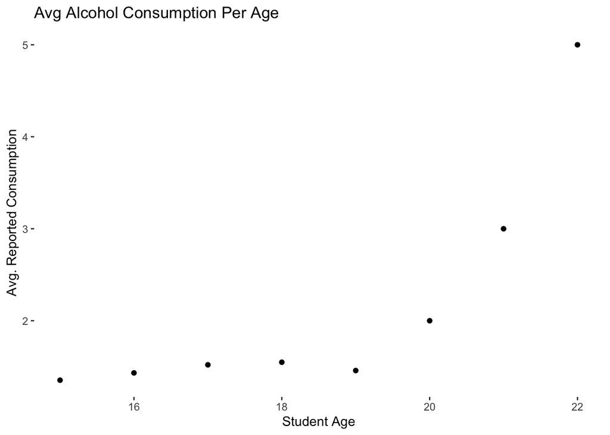

### Chart 3 (Yusen Liang)

I chose histogram to visualize the amount of drinking people in each drinking level for workdays. I divided the students with those who gained final grade greater than 60% and those who gained lower than 60% and see if those who have lower grade tend to have higher alcohol consumption index. I chose workdays’ consumption instead of weekends’ consumption because I think workdays’ consumption could be more significant factor to be considered regarding influences on grades. In the visualization, the darker graph is the work day alcohol consumption for students who gained more than 60% in final and the lighter graph is the work day alcohol consumption for students who gained less than 60% in final.However, visually the distribution of drinking level does not change significantly, most students have drinking level 1 for both groups and therefore this is not a very significant proof of drinking levels directly influences students’ final grades.

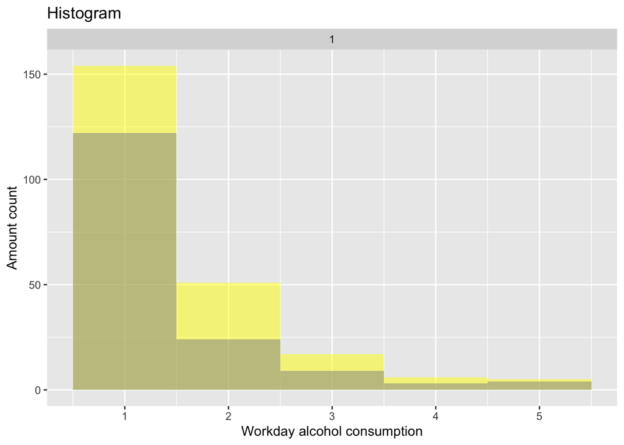